# R Notebook

# 4

What happens if you map the same variable to multiple aesthetics? Both are applied

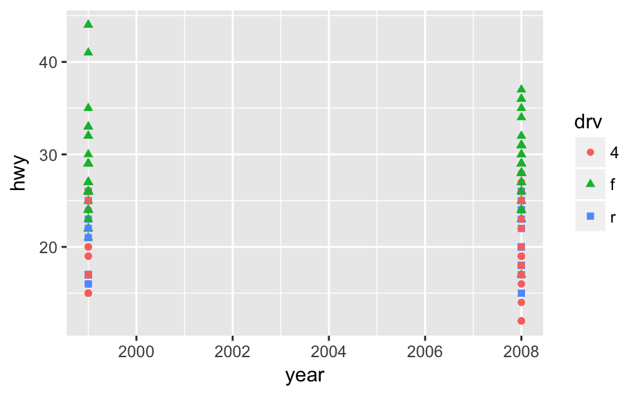

```r
 ggplot(data = mpg) +
  geom_point(mapping = aes(x = year, y = hwy, color = drv, shape=drv))
```

# 5 -

What does stroke do it supports over plotting scatter on numberic value.

```r
 ggplot(data = mpg) +
  geom_point(mapping = aes(x = cyl, y = trans, color=class, stroke = cyl))
?geom_point
```

[output not shown]

# 6

What happens if you map an aesthetic to something other than a variable name, like aes(colour = displ < 5)? It evaluates the expression and in this case returns true or false values.

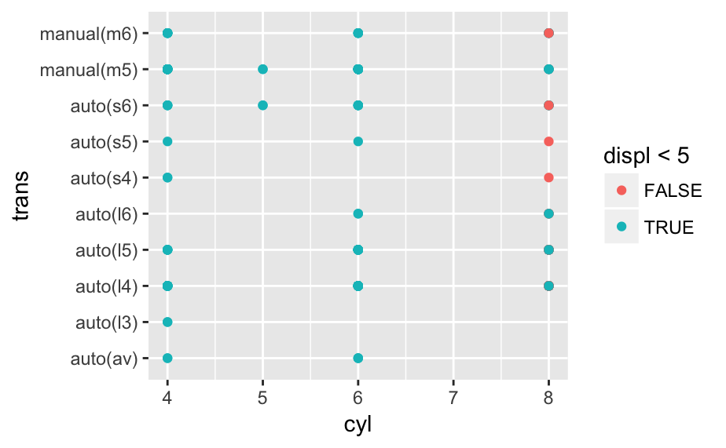

```r
 ggplot(data = mpg) +
  geom_point(mapping = aes(x = cyl, y = trans, color =displ < 5  ))
```

Section 3.5.1: #4 What are the advantages to using faceting instead of the colour aesthetic? What are the disadvantages? How might the balance change if you had a larger dataset? It breaks the data down into more manageable chunks in this case classifying them by class and putting in 2 rows

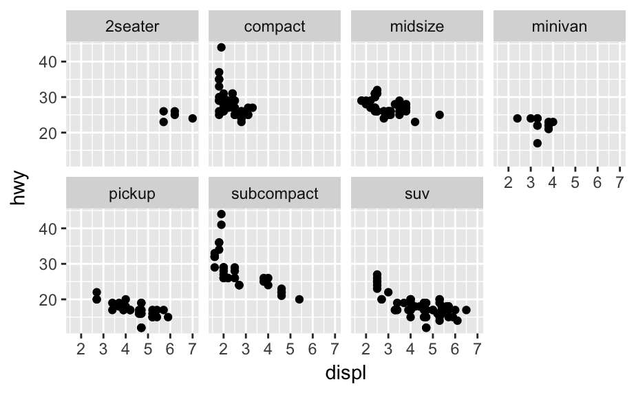

```r
ggplot(data = mpg) +
  geom_point(mapping = aes(x = displ, y = hwy)) +
  facet_wrap(~ class, nrow = 2)
```

# 5

Read ?facet_wrap. What does nrow do? What does ncol do? What other options control the layout of the individual panels? Why doesn’t facet_grid() have nrow and ncol argument? ?facet_wrap - splits the data into multiple chunks by to make better use of viewing screen. nrow - specifies number of rows ncol - number of columns Why doesn’t facet_grid() have nrow and ncol argument? need hellp with this one,..

```r
?facet_wrap
?facet_grid
?geom_a
```

```
No documentation for ‘geom_a’ in specified packages and libraries:
you could try ‘??geom_a’
```

Section 3.6.1: #1-5. #1 What geom would you use to draw a line chart? geom_line A boxplot? geom_boxplot A histogram? geom_hitogram An area chart? geom_area

# 2

Point map with smooth line

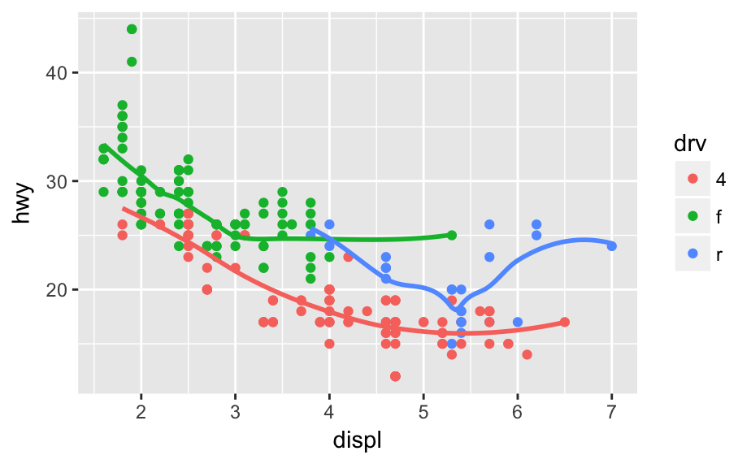

```r
ggplot(data = mpg, mapping = aes(x = displ, y = hwy, color = drv)) +
  geom_point() +
  geom_smooth(se = FALSE, show.legend = FALSE)
```

# 3

What does show.legend = FALSE do? It removed the legend message associated with that geom. What happens if you remove it? The dash associated with the line is not seen in the legend Why do you think I used it earlier in the chapter? It was not needed and could confuse the viewer

# 4

What does the se argument to geom_smooth() do? displays the confidence level (the grey shadow) if it is false does not display.

```r
?geom_smooth
```

# 5

Will these two graphs look different? Why/why not? No they should be the same they are different syntax to achieve the same goal.

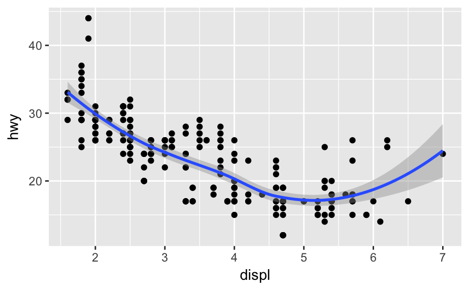

```r
ggplot(data = mpg, mapping = aes(x = displ, y = hwy)) +
  geom_point() +
  geom_smooth()
```

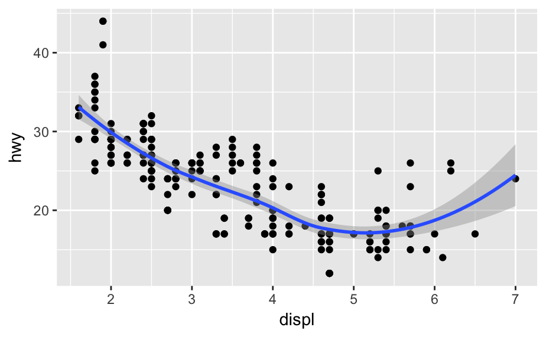

```r
ggplot() +
  geom_point(data = mpg, mapping = aes(x = displ, y = hwy)) +
  geom_smooth(data = mpg, mapping = aes(x = displ, y = hwy))
```

# 6

first Graph

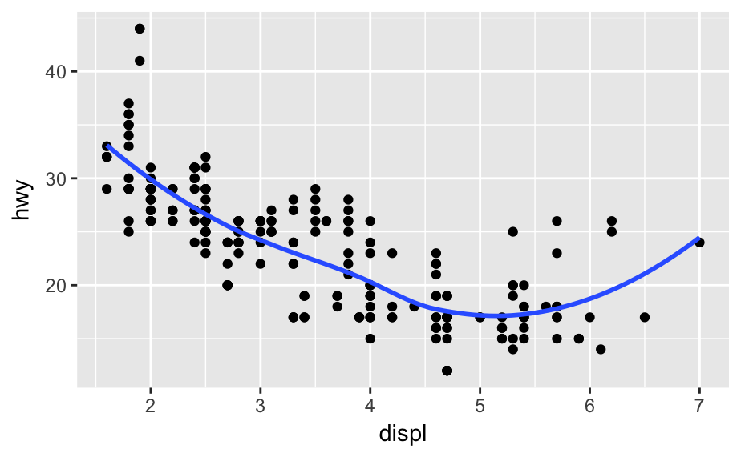

```r
ggplot(data = mpg, mapping = aes(x = displ, y = hwy)) +
  geom_point() +
  geom_smooth(se = FALSE)
```

Second Graph

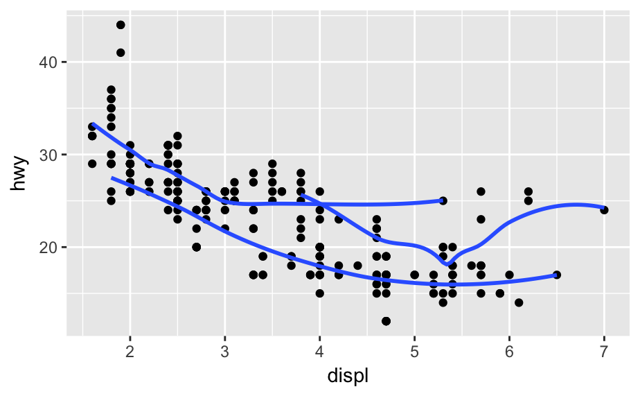

```r
ggplot(data = mpg, mapping = aes(x = displ, y = hwy, line=drv)) +
  geom_point() +
  geom_smooth(se = FALSE)
```

3rd Graph

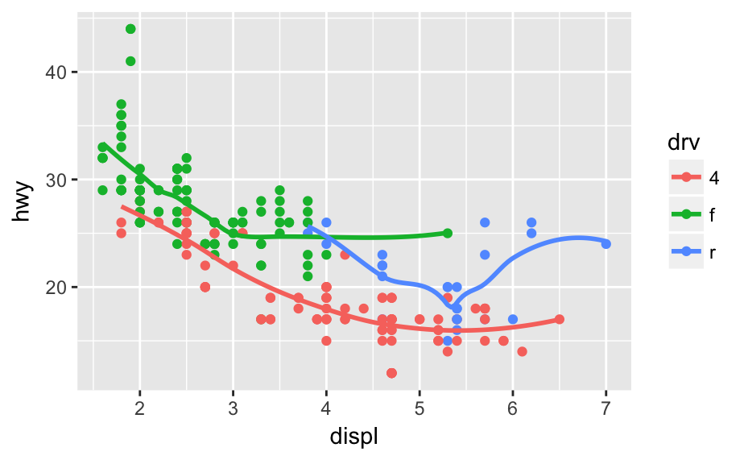

```r
ggplot(data = mpg, mapping = aes(x = displ, y = hwy, color=drv)) +
  geom_point() +
  geom_smooth(se = FALSE)
```

4th Graph

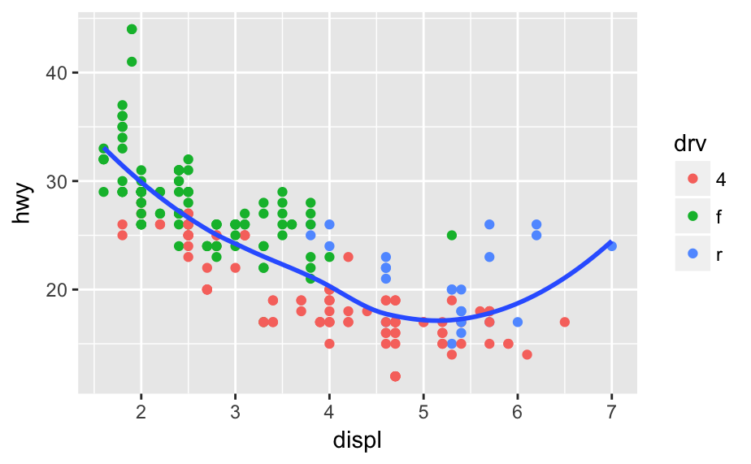

```r
ggplot(data = mpg, mapping = aes(x = displ, y = hwy,)) +
  geom_point(mapping = aes(color = drv)) +
  geom_smooth(se = FALSE)
```

5th Graph

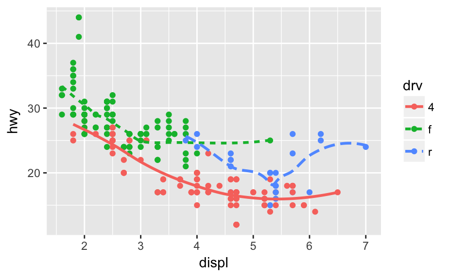

```r
ggplot(data = mpg, mapping = aes(x = displ, y = hwy, color=drv, linetype=drv)) +
  geom_point() +
  geom_smooth(se = FALSE)
```

6th Graph

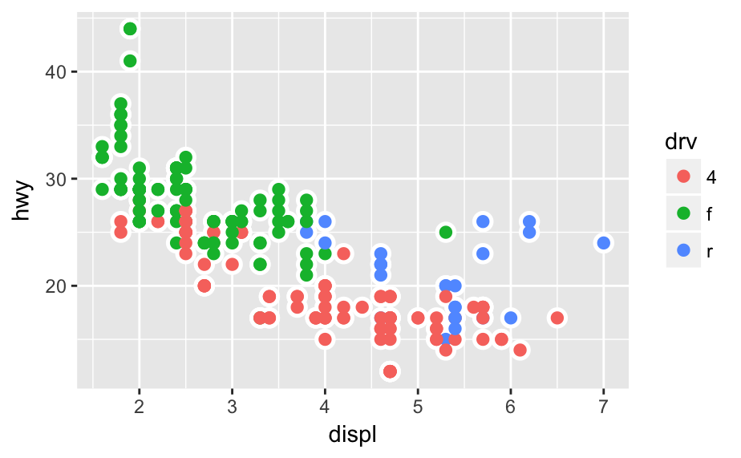

```r
ggplot(data = mpg, mapping = aes(x = displ, y = hwy, color=drv)) + geom_point(shape = 20, color="white", size = 2, stroke = 3)+
geom_point(shape = 20, size = 1, stroke = 2)
```

3.7.1: #2 geom_col uses height values geom_bar uses proportional data

Question on what is a Data Scientist - I would not have used the bar chart … in the first picture stories is confusing it looks like there is only 1% less than available talent unless you read all the stats - if you use pie chart use colors.. In th holw article it is hard to tell what the story is the use of black and blue doesn’t really present a picture of what they are trying to say.